# Statistical Learning

## 1.1 통계적 기계학습 Statistical learning

- 대표적 모형식: $y = f(x) + \epsilon$
  - $x$: 입력변수 (input variable), 설명변수 (explanatory variable), 독립변수 (independent variable), 특징변수 (feature)
  - $y$: 출력변수 (output variable), 반응변수 (response variable), 종속변수 (dependent variable), 타겟변수 (target variable)
  - $\epsilon$: 오차 (error)

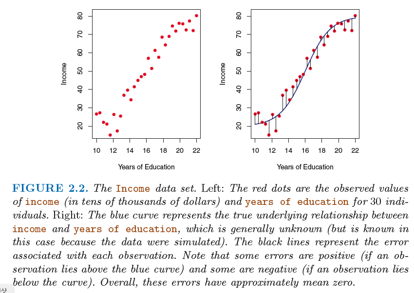

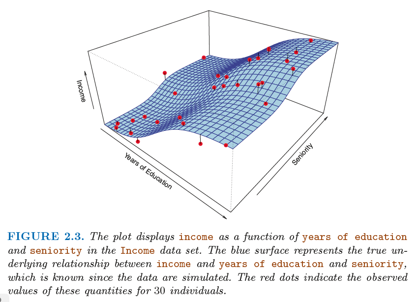

- 통계적 기계학습이란 데이터를 이용해 함수 $f$를 추정하는 접근법을 통틀어 가리키는 말
- 추정된 모형식 $f$를 이용해 예측(prediction) 및 추론(inference)에 활용
  - 예측: $f$에 대한 good estimate을 생성했고 $\epsilon$ 의 분산이 너무 크지 않을 경우, 새로운 $x$ 값에 대한 response $y$ 값을 정확히 예측할 수 있음
  - 추론: $y$ 와 $x$ 들의 관계 유형에 대해
    - 특히 어떤 예측 변수가 실제로 response 에 영향을 주는가?
    - 그 연관성이 positive 인가 negative 인가?
    - 그 연관성이 simple linear(단순 선형)인가 아니면 더 복잡한것 인가?

## 1.2 지도학습 Supervised learning

- 음성 인식, 얼굴 인식, 질병 진단 등과 같이 라벨(정답)이 있는 데이터를 분석한 모형을 이용
- 새로운 입력 데이터가 들어왔을 때 정확히 인식 내지 분류를 수행할 수 있도록 컴퓨터를 학습시키는 방법

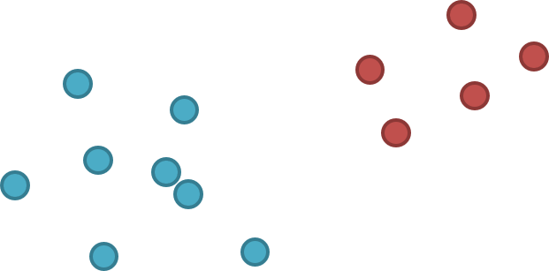

### 1.2.1 회귀/분류 Regression vs. classification

- 회귀분석(regression analysis)은 예측대상 변수와 특징변수들(features) 사이의 관계를 학습해 예측대상 변수의 값을 예측하는 것이 목표
- 분류(classification)는 예측 대상 변수가 클래스(class)임

### 1.2.2 학습데이터/시험데이터 training/test data

- 모형 학습이 예측 정확도를 담보할 수 있도록 하기 위해 주어진 데이터 전체를 학습에 사용하지 않고 학습용과 시험용으로 쪼개어 활용함
- 즉 학습용 데이터(training data)만을 사용해서 학습된 모형을 시험용 데이터(test data)에 적용한 예측 성능을 평가

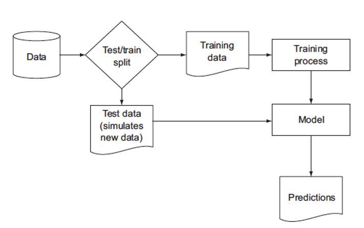

(출처: **Figure 5.1** in Zumel and Mount (2014), *Practical Data Science with R*, Manning)

### 1.2.3 학습 시 모형 정확도 평가

#### 회귀문제

- 회귀 모형 학습에는 보통 제곱오차(squared error, SE)을 손실함수로 사용: 예측대상 변수의 실제값을 $y$, 학습 알고리즘이 도출한 예측값을 $\tilde{y}$라 하면 제곱오차는
  $$L(\tilde{y}, y) = \frac{1}{2}(\tilde{y} - y)^2$$

#### 분류문제

- 분류 모형의 학습에는 보통 교차엔트로피(cross-entropy)를 손실함수로 사용: $y_k$를 실제 클래스에 대한 지시값(0/1), $\tilde{y}_k$를 클래스별 예측확률이라 하면 교차엔트로피는
  $$L(\tilde{y}, y) = -\sum_{k=1}^K y_{k} \log \tilde{y}_{k}$$

#### 과적합, 오버피팅 overfitting

- 머신러닝에서는 모형의 적합도(goodness-of-fit)보다는 예측 정확도를 더 중요하게 생각함
- 데이터의 모형 적합도를 지나치게 강조하게 되면 오버피팅(overfitting) 문제가 발생할 수 있기 때문

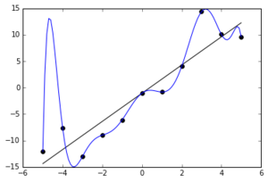

(By Ghiles - Own work, CC BY-SA 4.0, https://commons.wikimedia.org/w/index.php?curid=47471056)

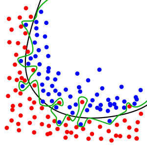

(출처: Wikipedia)

### 1.2.4 예측 정확도 평가

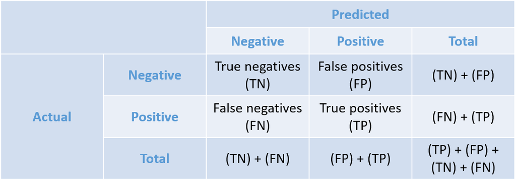

## 1.3 비지도학습 Unsupervised learning

- 데이터 내에 숨겨져 있는 의미있는 구조를 파악해 추상화하는 것이 목표임.
- 주로 입력 데이터 간의 유사성에 근거해 군집화하거나, 추상적인 개념을 측정하는 변수를 합성해 냄.

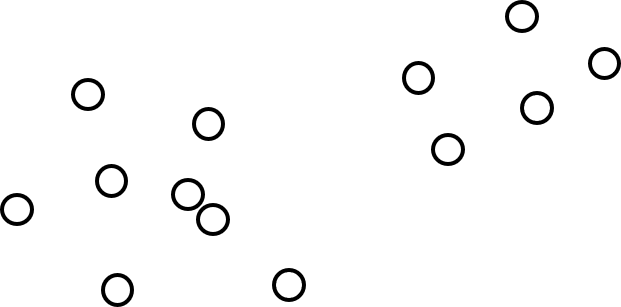

- 대표적 기법
  - 군집분석 Clustering
  - 밀도함수 추정 Density estimation
  - 가설 검정 Hypothesis testing, multiple testing
  - 차원 축소 Dimension reduction
  - 그래프 모형 Graphical models
  - 연관규칙 Association rules
- 일반적으로 지도학습에 비해 이론적 난이도가 높은 편임

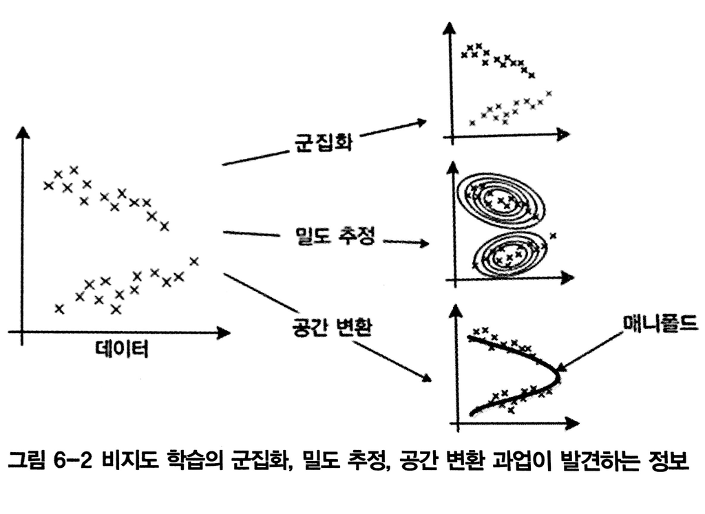

(출처: 오일석 (2017), 기계학습, 한빛미디어)

## 1.4 준지도학습 Semisupervised learning

- 라벨이 붙어있는 데이터와 붙어있지 않는 데이터가 섞여 있는 경우, 라벨이 없는 데이터에 라벨링을 하는 학습 알고리즘을 가리킴

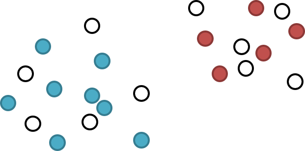

## 1.5 딥러닝 Deep learning

- 딥러닝 모형은 한 마디로 신경망모형의 층을 깊게 만든 머신러닝 모형임
- 층이 깊어지면서 층마다 이루어지는 비선형 변환기법의 조합을 통해 높은 수준의 추상화(데이터에 내재된 핵심적인 정보를 요약)를 기대할 수 있게 됨
- 최근 컴퓨팅 기술과 빅데이터 처리 기법이 발전함에 따라 가장 관심을 뜨겁게 받는 머신러닝 기법이 되었음

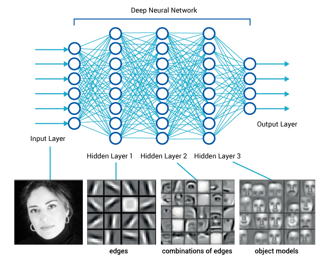

## 1.6 강화학습 Reinforcement learning

- 입력 데이터에 대해 ‘적절한’ 반응을 나타내면 보상을, 그렇지 않으면 벌점을 주는 과정을 순차적으로 시행하는 학습 방식임

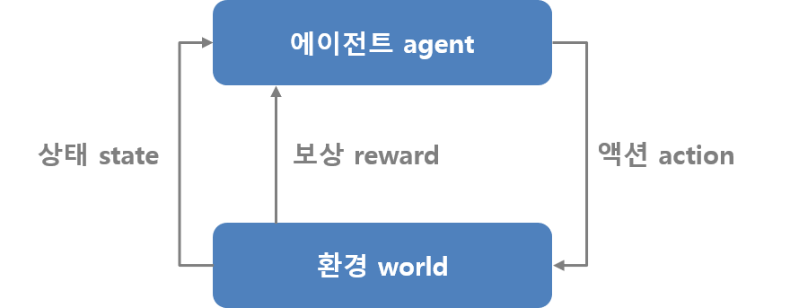

- 개념이 등장한 지는 꽤 오래 되었지만 영향력이 미미했으나, 최근 딥러닝이 자리잡으면서 그 진가를 드러내고 있는 중임
- 심층신경망이 학습한 표현(representation)과 강화학습의 에이전트의 귀납적 학습이 결합되어 놀라운 성과를 달성하고 있음